# Introduction

The gravity data used here is extracted from Budiman (1991) thesis "[Interpretation of gravity data over central Jawa [*sic*], Indonesia](https://librarysearch.adelaide.edu.au/permalink/61ADELAIDE_INST/rinku3/alma992913301811)". This data consists of 2811 complete Bouguer anomaly data collected during ground surveys in Central Java between 1965 to 1977, reduced using a Bouguer and terrain density of $2670\;\dfrac{kg}{m^3}$ from the observed gravity acceleration values. Gravity data X (Easting, in metres) and Y (Northing, in metres) positions are originally given in the local ["Batavia TM 109 SE"](https://epsg.io/2308) coordinate system, whose .wkt file are included in here and read using `pyproj.CRS.from_wkt` function. Gravity data elevation is sampled from [BATNAS'](https://sibatnas.big.go.id/) 200 m resolution DEM and bathymetry (using QGIS' `Raster analysis`>`Sample raster values`), so they are relative to the mean local sea level/geoid.

We cannot locate any explanation on this gravity data positioning techniques in the literature, so the gravity anomaly uncertainty cannot be estimated with any degree of certainty. Due to the absence of a reliable uncertainty estimate, the central Java gravity anomaly data presented here is *not good* for scientific publication but is good enough for experimenting with equivalent surface gridding technique as described in [Dampney (1969)](https://doi.org/10.1190/1.1439996).

So let's start!

# Import Packages

```python
import pandas as pd
import numpy as np
from pyproj import CRS, Transformer
from scipy import constants
# only the non-negative least square (NNLS) algorithm works well here.
# NNLS algorithm produce the least RMSE compared to cvxpy
# numpy.linalg, and scipy.linalg, while also
# produces sensible equivalent masses and
# resultant gridded gravity anomaly at the planar surface.
# The best thing about NNLS is it can work
# with any shape of "A's" in the b = Ax system
from scipy.optimize import nnls
from shapely.geometry import Point, MultiPolygon, Polygon  # For handling alpha shape
from SimPEG import utils as simpeg_utils
import supporting_functions as supportfuncs
import matplotlib.path as mpath
import matplotlib.pyplot as plt
import matplotlib.transforms as mtransforms
import warnings
```

# Define The Coordinate System

```python
# Step 1: Read the WKT string from the text file
with open("Batavia TM 109 SE WKT.txt", "r") as file:
    wkt_string = file.read().strip()

print("WKT string loaded successfully")
print(f"WKT length: {len(wkt_string)} characters")

# Step 2: Create CRS object from WKT
batavia_crs = CRS.from_wkt(wkt_string)
print(f"Custom CRS created: {batavia_crs.name}")

# Step 3: Target CRS, SRGI2013 / UTM zone 49S (EPSG:9489)
srgi_utm49s_crs = CRS.from_epsg(9489)

# Step 4: Create transformer
transformer = Transformer.from_crs(batavia_crs, srgi_utm49s_crs, always_xy=True)
```

```
WKT string loaded successfully
WKT length: 944 characters
Custom CRS created: Batavia / TM 109 SE
```

# Read The CSV File

```python
# Step 5: Read CSV file with X, Y coordinates
# Replace 'your_file.csv' with your actual CSV filename
csv_file = "grav_anom_jateng_with_elev.csv"  # Change this to your CSV filename
grav_data = pd.read_csv(csv_file, sep=';')

print(f"CSV loaded with {len(grav_data)} rows")
print("CSV columns:", grav_data.columns.tolist())
grav_data[:10]
```

```
CSV loaded with 2811 rows
CSV columns: ['Easting_M', 'Northing_M', 'Bouguer_anom', 'ELEV_M']
```

|  | Easting_M | Northing_M | Bouguer_anom | ELEV_M |
| --- | --- | --- | --- | --- |
| 0 | 673421.02 | 9225926.83 | -0.96 | 28.059452 |
| 1 | 665820.11 | 9224490.55 | -3.85 | 25.727678 |
| 2 | 668189.38 | 9224044.22 | -3.59 | 23.324348 |
| 3 | 670717.39 | 9223664.24 | -2.08 | 17.567015 |
| 4 | 668268.19 | 9221916.96 | -1.32 | 26.770287 |
| 5 | 665798.77 | 9219004.94 | -3.23 | 158.889557 |
| 6 | 668771.52 | 9217161.34 | 0.32 | 123.148232 |
| 7 | 668448.82 | 9219681.72 | 1.52 | 85.726646 |
| 8 | 666217.35 | 9215571.00 | 2.14 | 164.661774 |
| 9 | 667423.31 | 9214128.91 | 3.44 | 276.940277 |

# Transform The X and Y Coordinates to SRGI UTM Zone 49S

We now transform the Easting (X) and Northing (Y) of the local ["Batavia TM 109 SE"](https://epsg.io/2308) coordinate system to the current [SRGI UTM Zone 49S](https://epsg.io/9489) Easting (X) and Northing (Y). Both the Easting and Northing in the local "Batavia TM 109 SE" and SRGI UTM Zone 49S coordinate systems are in metres. This is to facilitate plotting in modern GIS softwares (like ArcGIS Pro and QGIS) and modules (like `cartopy` and `pygmt`).

```python
# Step 6: Transform coordinates
x_new, y_new = transformer.transform(grav_data["Easting_M"].values, grav_data["Northing_M"].values)

# Step 7: Add new columns
grav_data["SRGI_UTM49S_X"] = x_new
grav_data["SRGI_UTM49S_Y"] = y_new
grav_data["SRGI_UTM49S_X"] = grav_data["SRGI_UTM49S_X"].round(2) # round to two digit behind the dot
grav_data["SRGI_UTM49S_Y"] = grav_data["SRGI_UTM49S_Y"].round(2) # round to two digit behind the dot
grav_data[:10]
grav_data[['SRGI_UTM49S_X', 'SRGI_UTM49S_Y', 'ELEV_M', 'Bouguer_anom']].to_csv('SRGI13_grav_jateng_with_elev.csv', index=False)
```

# Calculating the Dampney's (1969) $\mathbf{A}$ Matrix

First, we need to know check the average central Java gravity data spacing ($\Delta x$), which is $\sim 2360\;\mathrm{m}$.

```python
grav_data_loc = grav_data[['SRGI_UTM49S_X','SRGI_UTM49S_Y','ELEV_M']].to_numpy()
grav_data_anom = grav_data[['Bouguer_anom']].to_numpy()
grav_data_anom = grav_data_anom.ravel()
average_data_spacing,_ = supportfuncs.calculate_average_gravity_spacing(grav_data_loc, method='2d', use_z=False)
average_data_spacing
```

```
Calculating 2D spacing for 2811 gravity data points...
```

```
2359.8845082540865
```

```python
dampney69_A_matrix, grid_mass_centres, eq_surface_elev, eq_depth_range = supportfuncs.Dampney_A(grav_data_loc)
```

```
Calculating 2D spacing for 2811 gravity data points...
Computing A matrix vectorized: 2811 x 1720
```

## What is the $\mathbf{A}$ matrix?

Assume a three dimensional, orthogonal $x,y,z$ coordinate system with positive $x$ to the right/east, positive $y$ to the front/north, and positive $z$ to the above/up. Given an array of $N$ masses $\mathbf{m} = \left[m_1, m_2, m_3, \dots, m_N\right]$ in this space, the gravity at a point $P\left(x,y,z\right)$ due to these masses is ([Roy, 1962](https://doi.org/10.1190/1.1438985); [Dampney, 1969](https://doi.org/10.1190/1.1439996))

$$g_P = \sum_{j=0}^{N}{a_{j}m_{j}} \tag{1}$$

with

$$a_j = \frac{K\times\left(z-h_{j}\right)}{\left\{\left(x-\alpha_{j}\right)^{2} + \left(y-\beta_{j}\right)^{2} + \left(z-h_{j}\right)^{2}\right\}^{3/2}}. \tag{2}$$

The original Dampney (1969) formulation puts $\left(h - z_{i}\right)$ since his coordinate system defines the positive $z$ axis downward/below.

The position of the i-th mass is given by $\left(\alpha_{j}, \beta_{j}, h_{j}\right)$ in three dimension. The array `grid_mass_centres` contains $\alpha_{j}, \beta_{j},$ and $h_{j}$ in the first, second, and third columns consecutively. Assuming all masses are laid on a flat plane at elevation $h$ (as `grid_mass_centres` does), then $h_{j} = h$ for all points and $a_{j}$ becomes

$$a_j = \frac{K\times\left(z-h\right)}{\left\{\left(x-\alpha_{j}\right)^{2} + \left(y-\beta_{j}\right)^{2} + \left(z-h\right)^{2}\right\}^{3/2}}. \tag{3}$$

If there are $K$ gravity values, $\mathbf{g} = \left[g_1, g_2, g_3, \dots, g_K\right]$, each located on $P_1\left(x_1, y_1, z_1\right), P_2\left(x_2, y_2, z_2\right), \dots, P_K\left(x_K, y_K, z_K\right),$ then the equation will be as follows.

$$\begin{bmatrix} g_1\\ g_2\\ g_3\\ \dots\\ g_K \end{bmatrix}= \begin{bmatrix} a_{11} & a_{12} & \dots & a_{1N} \\ a_{21} & a_{22} & \dots & a_{2N} \\ a_{31} & a_{32} & \dots & a_{3N} \\ \vdots & \vdots & \ddots & \vdots \\ a_{K1} & a_{K2} & \dots & a_{KN} \\ \end{bmatrix}\begin{bmatrix} m_1\\ m_2\\ m_3\\ \dots\\ m_N \end{bmatrix}. \tag{4}$$

In matrix form, the equation above can be expressed as

$$\mathbf{g} = \mathbf{A}\mathbf{m} \tag{5}$$

assuming ($\mathbf{A}$ is NOT necessarily square and can be sparse, too)

$$\mathbf{A}=\begin{bmatrix} a_{11} & a_{12} & \dots & a_{1N} \\ a_{21} & a_{22} & \dots & a_{2N} \\ a_{31} & a_{32} & \dots & a_{3N} \\ \vdots & \vdots & \ddots & \vdots \\ a_{K1} & a_{K2} & \dots & a_{KN} \\ \end{bmatrix} \tag{6}$$

and each $a_{ij} = \left\{a_{11}, a_{12}, \dots, a_{1N}, a_{21}, a_{22}, \dots, a_{KN} \right\}$ in $\mathbf{A}$ equals

$$a_{ij} = \frac{K\times\left(z_{i}-h\right)}{\left\{\left(x_{i}-\alpha_{j}\right)^{2} + \left(y_{i}-\beta_{j}\right)^{2} + \left(z_{i}-h\right)^{2}\right\}^{3/2}}. \tag{7}$$

## The Equivalent Surface Elevation, `eq_surface_elev`

Dampney (1969) gives a condition where the flat equivalent mass surface can be set under the gravity surveying level. In ground surveys, the condition put out by Dampney (1969) also means the range where the flat equivalent mass surface can be laid under the topography. The conditions described below is tied to the average gravity data spacing $\Delta x$.

$$2.5\Delta x<\left(z_{i}-h\right)<6\Delta x. \tag{8}$$

The original Dampney (1969) formulation puts $\left(h - z_{i}\right)$, because in his coordinate system, the level of equivalent layer is numerically larger/more positive than the topography.

We all understand that topographic surface is uneven. Then, Dampney (1969) gives this condition implicitly:

> The flat equivalent mass surface should lie at any depth between $\mathrm{min}\left(z\right)-2.5\Delta x$ and $\mathrm{max}\left(z\right)-6\Delta x$ (see Figure 1 below).

The `supportfuncs.Dampney_A` function above will increase the multiplication factor (the "6" in the "$6\Delta x$") of the $\mathrm{max}\left(z\right)-6\Delta x$ by 0.5 value increments if it finds that $\mathrm{max}\left(z\right)-6\Delta x\geq\mathrm{min}\left(z\right)-2.5\Delta x,$ i.e., it will try with (see the bolded number) $$\mathrm{max}\left(z\right)-\mathbf{6.5}\Delta x,$$ then $$\mathrm{max}\left(z\right)-\mathbf{7.0}\Delta x,$$ then $$\mathrm{max}\left(z\right)-\mathbf{7.5}\Delta x, \dots$$ until the condition of $\mathrm{max}\left(z\right)-\mathbf{b}\Delta x<\mathrm{min}\left(z\right)-2.5\Delta x$ is met, $\mathbf{b}$ being the multiplication factor being increased.

[figure not shown]

**Figure 1.** Grey area marks the range of equivalent mass surface/layer level under the topography as suggested in Dampney (1969), red line is midway between the upper and lower bound of that range. The `eq_depth_range=[upperBound, lowerBound]` array gives out the bounds obeyed by this notebook. This notebook's default gravity data gridding level (using the masses at the equivalent surface/level) is marked by the brown line.

By default, the `supportfuncs.Dampney_A` function will put the equivalent mass surface (or layer) halfway between the upper and lower bounds of the flat equivalent mass surface/layer's depth range (see the red line in Figure 1). However, users can define their own preferred depth range by passing a value to the `eq_surface_elev` argument in the `supportfuncs.Dampney_A` function {e.g., if you want an equivalent layer at -3 km below the mean sea level (the vertical datum depends on the vertical datum of your gravity data and may be different!) then you write `supportfuncs.Dampney_A(grav_data_loc, eq_surface_elev=-3000)` in your notebook or other development tools (Spyder, VSCode, or others).

# Searching for Suitable Mass Array $\mathbf{m}$

To this aim, we want to minimise the $\ell^2$[-norm](https://mathworld.wolfram.com/L2-Norm.html) $\left|\mathbf{A}\mathbf{m}-\mathbf{g} \right|_2$. However, $\mathbf{g}$ contains negative values, which may result in some negative values in $\mathbf{m}$, too. While this will be fine in MATLAB, I found it problematic in Python because the presence of negative masses in $\mathbf{m}$ makes the modelled gravity values extremely sensitive to the gravity anomaly gridding level. To ensure $\mathbf{g}$ (and $\mathbf{m}$) contains only zeroes and positive values, I first shifted the gravity data by subtracting the minimum gravity anomaly value from them.

`grav_data_anom_nonNeg = (grav_data_anom-grav_data_anom.min())`

$$\mathbf{g}_{\;(nonNeg)} = \mathbf{g}-\mathrm{min}\left(\mathbf{g}\right). \tag{9}$$

Then, I use `scipy.optimize.nnls` to [minimise](https://docs.scipy.org/doc/scipy/reference/generated/scipy.optimize.nnls.html) the $\left|\mathbf{A}\mathbf{m}-\mathbf{g}_{\;(nonNeg)} \right|_2$ without negative masses in $\mathbf{m}$. The resulting mass, when plugged back into the minimised equation, gives an RMSE of 4.4 mGal, good enough for progressing further! The relationship between the RMSE and the $\ell^2$[-norm](https://mathworld.wolfram.com/L2-Norm.html) is as follows.

$$\mathrm{RMSE\;(data\;unit)} = \sqrt{\frac{1}{K}\sum_{i=0}^{K}{\left\{\sum_{j=0}^{N}{\left(a_{ij}m_{j}\right)}-g_{i\;(nonNeg)}\right\}^2}} = \frac{\left | \mathbf{Am}-\mathbf{g}_{\;(nonNeg)}\right |_2}{\sqrt{K}}. \tag{10}$$

RMSE equals the $\ell^2$-norm divided by square root of $K$, the number of gravity data. Meanwhile, $N$ is the number of masses involved in the calculation above.

```python
# Suppose A is your (2000×8000) 2D array, grav is your length-2000 vector.
# Make sure both are NumPy arrays of dtype float64 (or float32).
grav_data_anom_nonNeg = (grav_data_anom-grav_data_anom.min())
mass_nnls, rnorm = nnls(dampney69_A_matrix, grav_data_anom_nonNeg)
#  • mass_nnls is a length-8000 array with all entries ≥ 0
#  • rnorm is the 2‐norm of the residual (‖A·mass_nnls − grav‖₂)

print("First 10 entries of mass:", mass_nnls[:10])
print("Residual norm |A·mass − grav|₂:", rnorm, " mGal")
print("RMSE |A·mass − grav|₂/√(len(grav)):", rnorm/np.sqrt(len(grav_data_anom_nonNeg)), " mGal")
```

```
First 10 entries of mass: [0. 0. 0. 0. 0. 0. 0. 0. 0. 0.]
Residual norm |A·mass − grav|₂: 234.85046343640715  mGal
RMSE |A·mass − grav|₂/√(len(grav)): 4.429564181604372  mGal
```

# Regridding the Gravity Anomaly at A Flat Surface Above the Topography

Once we have the non-negative masses array $\mathbf{m}$ ready, we can recalculate the gravity anomaly at any flat level above the topography. Gauss' law states that outside the source mass, gravity anomaly satisfies the Laplace's equation $\nabla^{2}\Phi=0$, with $\Phi$ as the gravity potential. The Laplace's equation is prerequisite for the applicability of gridding to interpolate gravity anomaly data, and by extension, this formula prohibits gridding *inside* the topography. Hence, the flat surface for gridding our gravity data should be at least touching/tangential to the topography or above.

The `supportfuncs.grav_at_planar_surf` function below by default puts the gridding surface 100 m above the highest data point in the survey area ($\approx$ highest topography in some cases, see Figure 1 above). However, users can set the elevation of the gridding surface by setting the `height_from_max_data_elev`, e.g. if they want to grid it at 2000 m above the highest data elevation, they can write `grav_at_planar_surf(grav_data_loc, mass_array, grid_mass_centres, eq_surface_elev, height_from_max_data_elev=2000)` in their development tools. Gridding resolution, i.e. the length of the sides of the square pixels in this grid, can be set by passing a positive **non-zero** value into the `supportfuncs.grav_at_planar_surf` function (e.g., if you want a 1-km = 1000-m grid resolution, you write `grav_at_planar_surf(grav_data_loc, mass_array, grid_mass_centres, eq_surface_elev, grid_res=1000)` in your development tool). Default grid resolution is as follows.

$$ \mathtt{default\_grid\_res} = 50\times\mathtt{np.round}\left(\frac{\mathtt{average\_gravity\_spacing}}{100}\right). \tag{11}$$

The function `supportfuncs.grav_at_planar_surf` calculates $a_{ij}$ in the $\mathbf{A}_{\,gridded}$ by setting the $z_{i} =$ maximum data elevation $+$ `height_from_max_data_elev` for all grid pixel centres (now $i$ stands for the $i$-th gravity grid pixel). Then, the gridded gravity is calculated by

$$\mathbf{g}_{\,gridded}=\mathbf{A}_{\,gridded}\;\mathbf{m}+\mathrm{min}\left(\mathbf{g}\right). \tag{12}$$

The $\mathrm{min}\left(\mathbf{g}\right)$ is brought back in (12) so the $\mathbf{g}_{\,gridded}$ has the same zero-anomaly datum with the original gravity anomaly data $\mathbf{g}$.

```python
gridded_grav_and_its_locs = supportfuncs.grav_at_planar_surf(grav_data_loc, mass_nnls, grid_mass_centres, eq_surface_elev)
gridded_grav_and_its_locs[:,3] = gridded_grav_and_its_locs[:,3]+grav_data_anom.min() # bringing back the non-negative gravity anomaly value to its real datum
```

```
Calculating 2D spacing for 2811 gravity data points...
Computing gridding A matrix vectorized: 31960 x 1720
```

# Finding the Survey Boundary Using the `alphashape`

Please modify the `alpha` [value](https://alphashape.readthedocs.io/en/latest/alphashape.html#module-alphashape) in the `supportfuncs.compute_alphashape_from_pts` function. The value of `alpha` is a real number. If `alpha=0` or less, `supportfuncs.compute_alphashape_from_pts` will return the convex hull boundary of the gravity data collection. Higher `alpha` will make the boundary tighter and tighter until no area is left at a very high `alpha` value. This boundary will be used to filter/mask out the gridded gravity data outside the original data extent/survey boundary.

```python
# Compute the alpha shape
alpha = 1e-4  # Adjust alpha to control concavity (smaller alpha = more concave)
grav_data_forAlphaShape = [tuple(round(x, 2) for x in sublist) for sublist in grav_data_loc[:,:2]]
grav_data_bound = supportfuncs.compute_alphashape_from_pts(grav_data_forAlphaShape, alpha)
```

## Plotting the Boundary

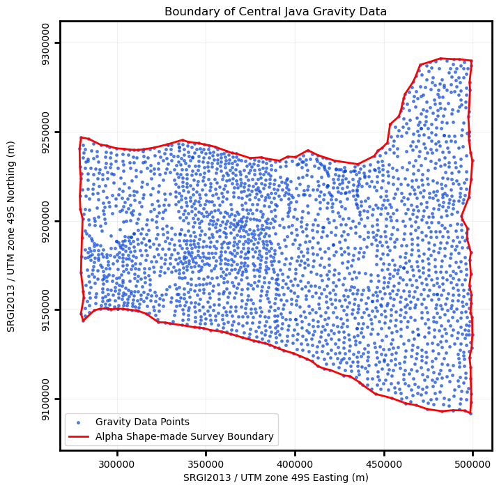

```python
import matplotlib.ticker as ticker

# Plot the points and alpha shape boundary
plt.figure(figsize=(8, 8))
plt.scatter(grav_data_loc[:, 0], grav_data_loc[:, 1], marker='.', c='xkcd:blue', s=25,
            label='Gravity Data Points', alpha=0.6, zorder=5)

# Extract the boundary coordinates from the alpha shape
if grav_data_bound.is_empty:
    print("Alpha shape is empty. Try increasing the alpha value.")
else:
    for poly in grav_data_bound.geoms:
        x, y = poly.exterior.xy
        plt.plot(x, y, color='red',
                 label='Alpha Shape-made Survey Boundary',
                 lw=2, zorder=6)

# Customize the plot
plt.xlabel('SRGI2013 / UTM zone 49S Easting (m)')
plt.ylabel('SRGI2013 / UTM zone 49S Northing (m)', rotation=90, labelpad=15)
plt.title('Boundary of Central Java Gravity Data')
plt.legend(loc='lower left')
plt.grid(True, zorder=1, alpha=0.2)
plt.axis('equal')  # Equal aspect ratio

# Set plot edge (spines) linewidth and make ticks stick outward
for spine in plt.gca().spines.values():
    spine.set_linewidth(2)
plt.gca().tick_params(axis='both', direction='out', length=6, width=2)

# Set custom tick formatter to show integers ending in "0000"
def custom_formatter(x, pos):
    # Find the nearest multiple of 10000
    return f'{int(np.floor(x / 50000) * 50000):d}'

plt.gca().xaxis.set_major_formatter(ticker.FuncFormatter(custom_formatter))
plt.gca().yaxis.set_major_formatter(ticker.FuncFormatter(custom_formatter))

# Set tick locator to place ticks at multiples of 10000
plt.gca().xaxis.set_major_locator(ticker.MultipleLocator(50000))
plt.gca().yaxis.set_major_locator(ticker.MultipleLocator(50000))

# Rotate y-axis tick labels to 90 degrees (bottom-to-top)
plt.gca().tick_params(axis='y', labelrotation=90)

# Rotate y-axis tick labels 90 degrees
for label in plt.gca().get_yticklabels():
    label.set_rotation(90)
    label.set_verticalalignment('center')   # Align vertically center to the tick
    label.set_horizontalalignment('right')  # Align horizontally so they sit beside the axis

# Adjust y-axis label position to align properly after rotation
plt.gca().yaxis.set_label_coords(-0.1, 0.5)  # Adjust label position if needed

plt.show()
```

## Filtering/Masking Out the Gridded Gravity Data Outside the Original Survey/Data Extent

```python
# Step 3: Mask grid points outside the alpha shape
mask = np.array([
    grav_data_bound.contains(Point(p)) or grav_data_bound.touches(Point(p))
    for p in gridded_grav_and_its_locs[:,:2]
])
masked_gridded_gravdata = gridded_grav_and_its_locs.copy()
masked_gridded_gravdata[~mask,3] = np.nan  # Set points outside alpha shape to NaN
masked_gridded_gravdata
```

```
array([[2.77200000e+05, 9.09000000e+06, 3.44298071e+03,            nan],
       [2.78400000e+05, 9.09000000e+06, 3.44298071e+03,            nan],
       [2.79600000e+05, 9.09000000e+06, 3.44298071e+03,            nan],
       ...,
       [4.99200000e+05, 9.29280000e+06, 3.44298071e+03,            nan],
       [5.00400000e+05, 9.29280000e+06, 3.44298071e+03,            nan],
       [5.01600000e+05, 9.29280000e+06, 3.44298071e+03,            nan]])
```

# Displaying the Gridded Gravity Data

```
(9050000.0, 9320000.0)
```

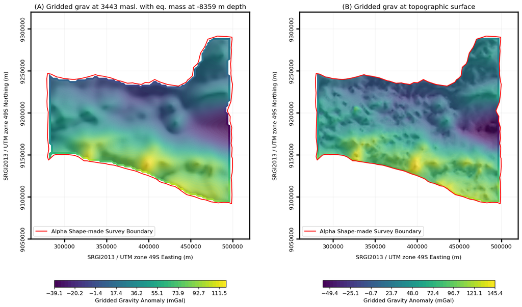

```python
# Step 5: Plot using SimPEG.utils.plot2Ddata
fig, ax = plt.subplots(1, 2, figsize=(16, 9), dpi=120)

# Gravity Anomaly Gridded at flat surface
grav_anom_plot = simpeg_utils.plot2Ddata(
    masked_gridded_gravdata[:, :3],  # x, y locations
    masked_gridded_gravdata[:, 3],   # Data values
    ax=ax[0],
    contourOpts={"cmap": "viridis",'zorder':4},
    ncontour=50,
    dataloc=False,  # Treat as ungridded data for interpolation
    shade=True,
    shadeOpts={"alpha": 0.3,'zorder':5},
    levelOpts={'zorder':4}
)

# Add horizontal colorbar below the plot
cbar = plt.colorbar(
    grav_anom_plot[0],
    ax=ax[0],
    orientation='horizontal',
    fraction=0.025,  # Scale the colorbar size (smaller value = smaller colorbar)
    aspect=25,      # Width-to-height ratio (larger value = thinner colorbar)
    pad=0.15,        # Space between plot and colorbar
    label="Gridded Gravity Anomaly (mGal)"
)

#ax.plot(grav_data_loc[:, 0], grav_data_loc[:, 1], 'b.', label='Data Points')  # Plot original points
for poly in grav_data_bound.geoms:
        x, y = poly.exterior.xy
        ax[0].plot(x, y, 'r-', label='Alpha Shape-made Survey Boundary', zorder=6)

# Customize the plot
ax[0].set_xlabel('SRGI2013 / UTM zone 49S Easting (m)', labelpad=10)
ax[0].set_ylabel('SRGI2013 / UTM zone 49S Northing (m)', rotation=90, labelpad=15)
ax[0].set_title('Boundary of Central Java Gravity Data')
ax[0].legend(loc='lower left')
ax[0].grid(True, zorder=1, alpha=0.2)
ax[0].set_aspect('equal')  # Equal aspect ratio

grid_grav_planeHeight = np.unique(gridded_grav_and_its_locs[:,2])[0]
title_fig_text = f"(A) Gridded grav at {grid_grav_planeHeight:.0f} masl. with eq. mass at {eq_surface_elev:.0f} m depth"
ax[0].set_title(title_fig_text)

# Set plot edge (spines) linewidth and make ticks stick outward
for spine in ax[0].spines.values():
    spine.set_linewidth(2)
ax[0].tick_params(axis='both', direction='out', length=6, width=2)

# Set custom tick formatter to show integers ending in "0000"
def custom_formatter(x, pos):
    # Find the nearest multiple of 10000
    return f'{int(np.floor(x / 50000) * 50000):d}'

ax[0].xaxis.set_major_formatter(ticker.FuncFormatter(custom_formatter))
ax[0].yaxis.set_major_formatter(ticker.FuncFormatter(custom_formatter))

# Set tick locator to place ticks at multiples of 10000
ax[0].xaxis.set_major_locator(ticker.MultipleLocator(50000))
ax[0].yaxis.set_major_locator(ticker.MultipleLocator(50000))

# Rotate y-axis tick labels to 90 degrees (bottom-to-top)
ax[0].tick_params(axis='y', labelrotation=90)

# Rotate y-axis tick labels 90 degrees
for label in ax[0].get_yticklabels():
    label.set_rotation(90)
    label.set_verticalalignment('center')   # Align vertically center to the tick
    label.set_horizontalalignment('right')  # Align horizontally so they sit beside the axis

# Adjust y-axis label position to align properly after rotation
ax[0].yaxis.set_label_coords(-0.1, 0.5)  # Adjust label position if needed
ax[0].set_xlim(260000,520000)
ax[0].set_ylim(9050000,9320000)

# Gravity Anomaly (Original)
grav_anom_plot = simpeg_utils.plot2Ddata(
    grav_data_loc,  # x, y locations
    grav_data_anom,   # Data values
    ax=ax[1],
    contourOpts={"cmap": "viridis",'zorder':4},
    ncontour=50,
    dataloc=False,  # Treat as ungridded data for interpolation
    shade=True,
    shadeOpts={"alpha": 0.3,'zorder':5},
    levelOpts={'zorder':4}
)

# Add horizontal colorbar below the plot
cbar = plt.colorbar(
    grav_anom_plot[0],
    ax=ax[1],
    orientation='horizontal',
    fraction=0.025,  # Scale the colorbar size (smaller value = smaller colorbar)
    aspect=25,      # Width-to-height ratio (larger value = thinner colorbar)
    pad=0.15,        # Space between plot and colorbar
    label="Gridded Gravity Anomaly (mGal)"
)

# Clip the contour plot to the alpha shape
if not grav_data_bound.is_empty:
    # Handle both Polygon and MultiPolygon cases
    if isinstance(grav_data_bound, (Polygon, MultiPolygon)):
        # Extract exterior coordinates from the alpha shape
        if isinstance(grav_data_bound, Polygon):
            x, y = grav_data_bound.exterior.xy
            vertices = np.column_stack((x, y))
        else:  # MultiPolygon
            # Use the first polygon or combine as needed; adjust based on your data
            x, y = grav_data_bound.geoms[0].exterior.xy
            vertices = np.column_stack((x, y))

        # Create a matplotlib Path from the alpha shape vertices
        clip_path = mpath.Path(vertices)

        # FIXED: Use transData instead of get_transform()
        # transData is the correct transform for data coordinates
        transformed_clip_path = mtransforms.TransformedPath(clip_path, ax[1].transData)

        # Apply the clip path ONLY to contour-related collections
        # Get the number of collections before plotting the boundary
        n_collections_before_boundary = len(ax[1].collections)

        # Apply clipping only to collections that are part of the contour plot
        # (exclude grid lines and other non-contour collections)
        for i, collection in enumerate(ax[1].collections):
            # Only clip collections that were created by the contour plot
            # Grid lines are typically the first collections, contours come after
            if hasattr(collection, 'get_paths') and len(collection.get_paths()) > 0:
                # This is likely a contour collection
                collection.set_clip_path(transformed_clip_path)

        # Also clip any QuadMesh objects (filled contours/pcolormesh) but be selective
        from matplotlib.collections import QuadMesh
        from matplotlib.image import AxesImage

        for child in ax[1].get_children():
            # Only clip contour-related objects, not spines, grid, etc.
            if isinstance(child, (QuadMesh, AxesImage)):
                try:
                    child.set_clip_path(transformed_clip_path)
                except:
                    pass

# Plot the boundary
for poly in grav_data_bound.geoms:
    x, y = poly.exterior.xy
    ax[1].plot(x, y, 'r-', label='Alpha Shape-made Survey Boundary', zorder=6)

# Customize the plot
ax[1].set_xlabel('SRGI2013 / UTM zone 49S Easting (m)', labelpad=10)
ax[1].set_ylabel('SRGI2013 / UTM zone 49S Northing (m)', rotation=90, labelpad=15)
ax[1].set_title('Boundary of Central Java Gravity Data')
ax[1].legend(loc='lower left')

# Set plot edge (spines) linewidth and make ticks stick outward
for spine in ax[1].spines.values():
    spine.set_linewidth(2)
    spine.set_visible(True)  # Ensure spines are visible

# Add grid AFTER clipping to ensure it's not affected
ax[1].grid(True, zorder=1, alpha=0.2)
ax[1].set_aspect('equal')  # Equal aspect ratio
grid_grav_planeHeight = np.unique(gridded_grav_and_its_locs[:,2])[0]
title_fig_text = r"(B) Gridded grav at topographic surface"
ax[1].set_title(title_fig_text)

# Set plot edge (spines) linewidth and make ticks stick outward
for spine in ax[1].spines.values():
    spine.set_linewidth(2)
ax[1].tick_params(axis='both', direction='out', length=6, width=2)

# Set custom tick formatter to show integers ending in "0000"
def custom_formatter(x, pos):
    # Find the nearest multiple of 10000
    return f'{int(np.floor(x / 50000) * 50000):d}'

ax[1].xaxis.set_major_formatter(ticker.FuncFormatter(custom_formatter))
ax[1].yaxis.set_major_formatter(ticker.FuncFormatter(custom_formatter))

# Set tick locator to place ticks at multiples of 10000
ax[1].xaxis.set_major_locator(ticker.MultipleLocator(50000))
ax[1].yaxis.set_major_locator(ticker.MultipleLocator(50000))

# Rotate y-axis tick labels to 90 degrees (bottom-to-top)
ax[1].tick_params(axis='y', labelrotation=90)

# Rotate y-axis tick labels 90 degrees
for label in ax[1].get_yticklabels():
    label.set_rotation(90)
    label.set_verticalalignment('center')   # Align vertically center to the tick
    label.set_horizontalalignment('right')  # Align horizontally so they sit beside the axis

# Adjust y-axis label position to align properly after rotation
ax[1].yaxis.set_label_coords(-0.1, 0.5)  # Adjust label position if needed
ax[1].set_xlim(260000,520000)
ax[1].set_ylim(9050000,9320000)
```

## Export the Gridded Gravity Data to Surfer v7 GRD Grid Format for Portability

```python
grid_grav_planeHeight = np.unique(gridded_grav_and_its_locs[:,2])[0]
supportfuncs.export_to_surfer_grd7(masked_gridded_gravdata, f"grav_gridded_at_{grid_grav_planeHeight:.2f}_m.grd", grid_crs=srgi_utm49s_crs)
```

```
Grid dimensions: 188 x 170
X range: 277200.00 to 501600.00
Y range: 9090000.00 to 9292800.00
Using driver: GS7BG
Set CRS from PyProj CRS object: EPSG:9489
Successfully exported to grav_gridded_at_3442.98_m.grd
Valid data points: 18744 out of 31960 grid cells
```